# Zotero group TCA

Published

16 October 2026

Zotero data of 16 October 2026 · IPBES Literature Report 0.4.0 · [source code on GitHub](https://github.com/IPBES-Data/IPBES.LiteratureReport)

This report shows the state of the Zotero group **TCA** ([open the group in Zotero](https://www.zotero.org/groups/4589462)). It gives an overview of the literature in the group, and lists the items which should be corrected.

Each item in the lists can be opened in the Zotero **web** library or in the Zotero **app** on your computer, so that it can be corrected directly. Corrected items disappear from the lists the next time the report is updated. Some checks compare the items with [OpenAlex](https://openalex.org), an open catalogue of scholarly publications.

## Summary

| Status | Check | Items |
| --- | --- | --- |
| ● OK | Retracted publications | 0 |
| ● Please fix | DOI points to a different publication | 104 |
| ● Please fix | Items which are in the group more than once | 1 |
| ● OK | DOI field with an invalid DOI | 0 |
| ● Please fix | DOI field with a link or prefix instead of the DOI | 34 |
| ● Please check | ISSN not in the standard form | 246 |
| ● Please check | DOI in the wrong field | 30 |
| ● Please check | DOI not found in OpenAlex | 34 |
| ● Please check | Missing or unusual publication year | 1394 |
| ● Please check | Empty journal, volume, issue or pages, found in OpenAlex | 343 |
| ● Please check | Language not given as a language code | 185 |
| ● Please check | Items without DOI, ISBN, ISSN or URL | 1187 |
| ● Please check | Items without DOI, for which OpenAlex has one | 226 |
| ● OK | OpenAlex ID in Extra not valid | 0 |
| ● For information | Items without their OpenAlex ID in Extra | 1693 |
| ● For information | Items without tags | 1165 |

**Please fix**: these items contain errors. **Please check**: these items may need a correction. **For information**: no action needed unless the group uses this, e.g. tags.

## Items to fix

The lists are sorted by importance. Use the search field above a list to find an item. **web** opens the item in the Zotero web library, **app** in the Zotero app.

### Retracted publications

These publications have been retracted. Check whether they should still be cited, and mark or remove them in Zotero.

**✔ Nothing to fix.**

### DOI points to a different publication

The DOI of these items leads to a publication with a different title or year. Usually the DOI is wrong: open the DOI to see where it leads, and correct it in Zotero. Differences of one year (e.g. published online before print) are not listed.

| Open in Zotero | Title in Zotero | Year in Zotero | The DOI leads to | Its year | DOI |
| --- | --- | --- | --- | --- | --- |
| <a href="https://www.zotero.org/groups/4589462/items/2L9LEKZC" target="_blank">web</a> &middot; <a href="zotero://select/groups/4589462/items/2L9LEKZC">app</a> | Co-production in global sustainability: Histories and theories | 2020 | Co-production in global sustainability: Histories and theories | 2018 | <a href="https://doi.org/10.1016/j.envsci.2018.01.016" target="_blank">10.1016/j.envsci.2018.01.016</a> |
| <a href="https://www.zotero.org/groups/4589462/items/J2JLLV2L" target="_blank">web</a> &middot; <a href="zotero://select/groups/4589462/items/J2JLLV2L">app</a> | The influence of nudges on compliance behaviour in recreational fisheries: A laboratory experiment | 2021 | The influence of nudges on compliance behaviour in recreational fisheries: a laboratory experiment | 2019 | <a href="https://doi.org/10.1093/icesjms/fsz020" target="_blank">10.1093/icesjms/fsz020</a> |
| <a href="https://www.zotero.org/groups/4589462/items/IP4I76Q6" target="_blank">web</a> &middot; <a href="zotero://select/groups/4589462/items/IP4I76Q6">app</a> | Co-becoming Bawaka: Towards a relational understanding of place/space | 2016 | Co-becoming Bawaka | 2015 | <a href="https://doi.org/10.1177/0309132515589437" target="_blank">10.1177/0309132515589437</a> |
| <a href="https://www.zotero.org/groups/4589462/items/QZFDJH5B" target="_blank">web</a> &middot; <a href="zotero://select/groups/4589462/items/QZFDJH5B">app</a> | Environmental policy integration among multilateral environmental agreements: the case of biodiversity | 2016 | Environmental policy integration among multilateral environmental agreements: the case of biodiversity | 2014 | <a href="https://doi.org/10.1007/s10784-014-9263-4" target="_blank">10.1007/s10784-014-9263-4</a> |
| <a href="https://www.zotero.org/groups/4589462/items/TSGTCN3I" target="_blank">web</a> &middot; <a href="zotero://select/groups/4589462/items/TSGTCN3I">app</a> | Towards a Natural Social Contract: Transformative Social-Ecological Innovation for a Sustainable, Healthy and Just Society | 2021 | Towards a Natural Social Contract | 2021 | <a href="https://doi.org/10.1007/978-3-030-67130-3" target="_blank">10.1007/978-3-030-67130-3</a> |
| <a href="https://www.zotero.org/groups/4589462/items/J3THNBH8" target="_blank">web</a> &middot; <a href="zotero://select/groups/4589462/items/J3THNBH8">app</a> | Tax Avoidance as a Sustainability Problem | 2018 | Tax Avoidance as a Sustainability Problem | 2016 | <a href="https://doi.org/10.1007/s10551-016-3162-2" target="_blank">10.1007/s10551-016-3162-2</a> |
| <a href="https://www.zotero.org/groups/4589462/items/Z72QVAJ7" target="_blank">web</a> &middot; <a href="zotero://select/groups/4589462/items/Z72QVAJ7">app</a> | Agricultural policy for biodiversity: Facilitators and barriers for transformation | 2021 | Agricultural Policy for Biodiversity: Facilitators and Barriers for Transformation | 2016 | <a href="https://doi.org/10.3390/books978-3-03897-879-4-13" target="_blank">10.3390/books978-3-03897-879-4-13</a> |
| <a href="https://www.zotero.org/groups/4589462/items/EM7SYZZ3" target="_blank">web</a> &middot; <a href="zotero://select/groups/4589462/items/EM7SYZZ3">app</a> | Three Decades of Policy Layering and Politically Sustainable Reform in the <span style="font-variant:small-caps;">E</span> uropean <span style="font-variant:small-caps;">U</span> nion's Agricultural P… | 2016 | Three Decades of Policy Layering and Politically Sustainable Reform in the E uropean U nion's Agricultural Policy | 2015 | <a href="https://doi.org/10.1111/gove.12171" target="_blank">10.1111/gove.12171</a> |
| <a href="https://www.zotero.org/groups/4589462/items/Z7CIZ9H5" target="_blank">web</a> &middot; <a href="zotero://select/groups/4589462/items/Z7CIZ9H5">app</a> | Bonds to Finance the Sustainable Blue Economy: A Practitioner's Guide | 2023 | Bonds to Finance the Sustainable Blue Economy | 2023 | <a href="https://doi.org/10.22617/tcs230328-2" target="_blank">10.22617/tcs230328-2</a> |
| <a href="https://www.zotero.org/groups/4589462/items/9C4QKF7V" target="_blank">web</a> &middot; <a href="zotero://select/groups/4589462/items/9C4QKF7V">app</a> | Greening the international monetary system? Not without addressing the political ecology of global imbalances | 2022 | Greening the international monetary system? Not without addressing the political ecology of global imbalances | 2020 | <a href="https://doi.org/10.1080/09692290.2020.1854326" target="_blank">10.1080/09692290.2020.1854326</a> |

[output cut: 94 more lines]

### Items which are in the group more than once

These items are in the group more than once, with the same DOI, or with the same title, year and first author. Keep one copy and merge or delete the others, e.g. with *Duplicate Items* in the Zotero app.

| Open in Zotero | Title | Copies |
| --- | --- | --- |
| <a href="https://www.zotero.org/groups/4589462/items/Z9V5LWVS" target="_blank">web</a> &middot; <a href="zotero://select/groups/4589462/items/Z9V5LWVS">app</a><br><a href="https://www.zotero.org/group… | Crises of Inequality: Shifting Power for a New Eco-Social Contract | 2 |

### DOI field with an invalid DOI

The DOI field of these items contains something which is not a valid DOI. Correct or remove it.

**✔ Nothing to fix.**

### DOI field with a link or prefix instead of the DOI

The DOI field of these items contains the DOI as a link (`https://doi.org/…`) or with a prefix (`DOI …`). Citation styles add the link themselves, so it would appear twice. Replace it with the DOI only.

| Open in Zotero | Title | Content of the DOI field | DOI |
| --- | --- | --- | --- |
| <a href="https://www.zotero.org/groups/4589462/items/H4D6F2KC" target="_blank">web</a> &middot; <a href="zotero://select/groups/4589462/items/H4D6F2KC">app</a> | Do we need a new science-policy interface for food systems ? | https://doi.org/10.1126/science.abj5263 | <a href="https://doi.org/10.1126/science.abj5263" target="_blank">10.1126/science.abj5263</a> |
| <a href="https://www.zotero.org/groups/4589462/items/J2JLLV2L" target="_blank">web</a> &middot; <a href="zotero://select/groups/4589462/items/J2JLLV2L">app</a> | The influence of nudges on compliance behaviour in recreational fisheries: A laboratory experiment | https://doi.org/10.1093/icesjms/fsz020 | <a href="https://doi.org/10.1093/icesjms/fsz020" target="_blank">10.1093/icesjms/fsz020</a> |
| <a href="https://www.zotero.org/groups/4589462/items/L7Z9GIHY" target="_blank">web</a> &middot; <a href="zotero://select/groups/4589462/items/L7Z9GIHY">app</a> | Mainstreaming Biodiversity: Conservation for the Twenty-First Century | https://doi.org/10.3389/fevo.2015.00137 | <a href="https://doi.org/10.3389/fevo.2015.00137" target="_blank">10.3389/fevo.2015.00137</a> |
| <a href="https://www.zotero.org/groups/4589462/items/PQDGAQZR" target="_blank">web</a> &middot; <a href="zotero://select/groups/4589462/items/PQDGAQZR">app</a> | Global land-use and land-cover data for ecologists: Historical, current, and future scenarios | https://doi.org/10.17161/bi.v16i1.15483 | <a href="https://doi.org/10.17161/bi.v16i1.15483" target="_blank">10.17161/bi.v16i1.15483</a> |
| <a href="https://www.zotero.org/groups/4589462/items/T4VVXI85" target="_blank">web</a> &middot; <a href="zotero://select/groups/4589462/items/T4VVXI85">app</a> | Global trends in world fisheries: impacts on marine ecosystems and food security | doi:10.1098/rstb.2004.1574 | <a href="https://doi.org/10.1098/rstb.2004.1574" target="_blank">10.1098/rstb.2004.1574</a> |
| <a href="https://www.zotero.org/groups/4589462/items/Y7XPFMLH" target="_blank">web</a> &middot; <a href="zotero://select/groups/4589462/items/Y7XPFMLH">app</a> | Identifying key knowledge gaps to better protect biodiversity and simultaneously secure livelihoods in a priority conservation area | https://doi.org/10.3390/su11205695 | <a href="https://doi.org/10.3390/su11205695" target="_blank">10.3390/su11205695</a> |
| <a href="https://www.zotero.org/groups/4589462/items/9LDGC7K3" target="_blank">web</a> &middot; <a href="zotero://select/groups/4589462/items/9LDGC7K3">app</a> | Futures of global urban expansion: uncertainties and implications for biodiversity conservation | DOI 10.1088/1748-9326/8/1/014025 | <a href="https://doi.org/10.1088/1748-9326/8/1/014025" target="_blank">10.1088/1748-9326/8/1/014025</a> |
| <a href="https://www.zotero.org/groups/4589462/items/N5XA324S" target="_blank">web</a> &middot; <a href="zotero://select/groups/4589462/items/N5XA324S">app</a> | Urbanization in Africa: challenges and opportunities for conservation | DOI 10.1088/1748-9326/aa94fe | <a href="https://doi.org/10.1088/1748-9326/aa94fe" target="_blank">10.1088/1748-9326/aa94fe</a> |
| <a href="https://www.zotero.org/groups/4589462/items/A38W3PRL" target="_blank">web</a> &middot; <a href="zotero://select/groups/4589462/items/A38W3PRL">app</a> | Solid waste management in the context of a circular economy in the MENA region | doi.org/10.3390/su14010480 | <a href="https://doi.org/10.3390/su14010480" target="_blank">10.3390/su14010480</a> |
| <a href="https://www.zotero.org/groups/4589462/items/6XB873RB" target="_blank">web</a> &middot; <a href="zotero://select/groups/4589462/items/6XB873RB">app</a> | Global Warming of 1.5°C. An IPCC Special Report on the impacts of global warming of 1.5°C above pre-industrial levels and related global greenhouse gas emission pathways, in the context of strengtheni… | 10.1017/9781009157940. | <a href="https://doi.org/10.1017/9781009157940" target="_blank">10.1017/9781009157940</a> |

[output cut: 24 more lines]

### ISSN not in the standard form

The ISSN field of these items is not in the standard form `1234-567X` (several separated by “,”), or contains something which is not a valid ISSN, e.g. an ISBN.

| Open in Zotero | Title | Content of the ISSN field | Standard form | Not a valid ISSN |
| --- | --- | --- | --- | --- |
| <a href="https://www.zotero.org/groups/4589462/items/E3EV4SBN" target="_blank">web</a> &middot; <a href="zotero://select/groups/4589462/items/E3EV4SBN">app</a> | Discourse coalitions for sustainability transformations: common ground and conflict beyond neoliberalism | 18773435 | 1877-3435 | NA |
| <a href="https://www.zotero.org/groups/4589462/items/B6IH6QRP" target="_blank">web</a> &middot; <a href="zotero://select/groups/4589462/items/B6IH6QRP">app</a> | The living infinite: Envisioning futures for transformed human-nature relationships on the high seas | 0308597X | 0308-597X | NA |
| <a href="https://www.zotero.org/groups/4589462/items/73W5FAFU" target="_blank">web</a> &middot; <a href="zotero://select/groups/4589462/items/73W5FAFU">app</a> | Integrating the four faces of climate change adaptation: Towards transformative change in Guatemalan coffee communities | 0305750X | 0305-750X | NA |
| <a href="https://www.zotero.org/groups/4589462/items/QXVMYXU9" target="_blank">web</a> &middot; <a href="zotero://select/groups/4589462/items/QXVMYXU9">app</a> | ‘Raising the temperature’: the arts on a warming planet | 18773435 | 1877-3435 | NA |
| <a href="https://www.zotero.org/groups/4589462/items/LZ3T5QLY" target="_blank">web</a> &middot; <a href="zotero://select/groups/4589462/items/LZ3T5QLY">app</a> | Colonial modernity and sustainability transitions: A conceptualisation in six dimensions | 22104224 | 2210-4224 | NA |
| <a href="https://www.zotero.org/groups/4589462/items/T4TMJ4MR" target="_blank">web</a> &middot; <a href="zotero://select/groups/4589462/items/T4TMJ4MR">app</a> | A Roadmap for Using the UN Decade of Ocean Science for Sustainable Development in Support of Science, Policy, and Action | 25903322 | 2590-3322 | NA |
| <a href="https://www.zotero.org/groups/4589462/items/7G8ULY7E" target="_blank">web</a> &middot; <a href="zotero://select/groups/4589462/items/7G8ULY7E">app</a> | Enabling new mindsets and transformative skills for negotiating and activating climate action: Lessons from UNFCCC conferences of the parties | 14629011 | 1462-9011 | NA |
| <a href="https://www.zotero.org/groups/4589462/items/P7RBN65Z" target="_blank">web</a> &middot; <a href="zotero://select/groups/4589462/items/P7RBN65Z">app</a> | Engaging and empowering people in biodiversity conservation: lessons from practice | 07917945 | 0791-7945 | NA |
| <a href="https://www.zotero.org/groups/4589462/items/5ZX7B83S" target="_blank">web</a> &middot; <a href="zotero://select/groups/4589462/items/5ZX7B83S">app</a> | The means determine the end – Pursuing integrated valuation in practice | 22120416 | 2212-0416 | NA |
| <a href="https://www.zotero.org/groups/4589462/items/V8VES3LW" target="_blank">web</a> &middot; <a href="zotero://select/groups/4589462/items/V8VES3LW">app</a> | Valuing nature's contributions to people: the IPBES approach | 18773435 | 1877-3435 | NA |

[output cut: 236 more lines]

### DOI in the wrong field

These items have no DOI in the DOI field, but a DOI in the URL or Extra field. Copy the DOI into the DOI field.

| Open in Zotero | Title | DOI in URL | DOI in Extra |
| --- | --- | --- | --- |
| <a href="https://www.zotero.org/groups/4589462/items/M8UXQ4L3" target="_blank">web</a> &middot; <a href="zotero://select/groups/4589462/items/M8UXQ4L3">app</a> | Slowing Amazon deforestation through public policy and interventions in beef and soy supply chains \| Science | <a href="https://doi.org/10.1126/science.1248525" target="_blank">10.1126/science.1248525</a> |  |
| <a href="https://www.zotero.org/groups/4589462/items/AWPGIBCB" target="_blank">web</a> &middot; <a href="zotero://select/groups/4589462/items/AWPGIBCB">app</a> | Indigenous environmental justice: Anti-colonial action through kinship | <a href="https://doi.org/10.4324/9780429029585-23/indigenous-environmental-justice-kyle-whyte" target="_blank">10.4324/9780429029585-23/indigenous-environmental-justice-kyle-whyte</a> |  |
| <a href="https://www.zotero.org/groups/4589462/items/FEETBA4X" target="_blank">web</a> &middot; <a href="zotero://select/groups/4589462/items/FEETBA4X">app</a> | Globalization’s limits to the environmental state? Integrating telecoupling into global environmental governance | <a href="https://doi.org/10.1080/09644016.2015.1074384" target="_blank">10.1080/09644016.2015.1074384</a> |  |
| <a href="https://www.zotero.org/groups/4589462/items/F3GZDKA6" target="_blank">web</a> &middot; <a href="zotero://select/groups/4589462/items/F3GZDKA6">app</a> | Capital and Ideology | <a href="https://doi.org/10.4159/9780674245075/html" target="_blank">10.4159/9780674245075/html</a> | <a href="https://doi.org/10.4159/9780674245075" target="_blank">10.4159/9780674245075</a> |
| <a href="https://www.zotero.org/groups/4589462/items/PGYJ9GDQ" target="_blank">web</a> &middot; <a href="zotero://select/groups/4589462/items/PGYJ9GDQ">app</a> | Impacts of agricultural policies on productivity and sustainability performance in agriculture: A literature review | <a href="https://doi.org/10.1787/18156797" target="_blank">10.1787/18156797</a> |  |
| <a href="https://www.zotero.org/groups/4589462/items/GZCP6JX6" target="_blank">web</a> &middot; <a href="zotero://select/groups/4589462/items/GZCP6JX6">app</a> | Missing links: technology and environment implications in the industrializing world |  | <a href="https://doi.org/10.1524/jbwg.2009.50.2.9" target="_blank">10.1524/jbwg.2009.50.2.9</a> |
| <a href="https://www.zotero.org/groups/4589462/items/K5983AUJ" target="_blank">web</a> &middot; <a href="zotero://select/groups/4589462/items/K5983AUJ">app</a> | Marine Technology Transfer: Towards a Capacity-Building Toolkit for Marine Biodiversity beyond National Jurisdiction | <a href="https://doi.org/10.1163/j.ctv1sr6jp5.19" target="_blank">10.1163/j.ctv1sr6jp5.19</a> |  |
| <a href="https://www.zotero.org/groups/4589462/items/YJGMILQJ" target="_blank">web</a> &middot; <a href="zotero://select/groups/4589462/items/YJGMILQJ">app</a> | Rebound effect and sustainability science: A review | <a href="https://doi.org/10.1111/jiec.13295" target="_blank">10.1111/jiec.13295</a> |  |
| <a href="https://www.zotero.org/groups/4589462/items/9RZAA9RP" target="_blank">web</a> &middot; <a href="zotero://select/groups/4589462/items/9RZAA9RP">app</a> | Uncomfortable knowledge: the social construction of ignorance in science and environmental policy discourses | <a href="https://doi.org/10.4324/9781315771106" target="_blank">10.4324/9781315771106</a> |  |
| <a href="https://www.zotero.org/groups/4589462/items/8DVTF8PG" target="_blank">web</a> &middot; <a href="zotero://select/groups/4589462/items/8DVTF8PG">app</a> | Regional Assessment of Africa | <a href="https://doi.org/10.1007/978-94-007-7088-1_23" target="_blank">10.1007/978-94-007-7088-1_23</a> |  |

[output cut: 20 more lines]

### DOI not found in OpenAlex

These DOIs were not found in OpenAlex. The DOI may be wrong: open it to check. If it leads to the right publication, the publication is simply not (yet) in OpenAlex and nothing needs to be done.

| Open in Zotero | Title | DOI |
| --- | --- | --- |
| <a href="https://www.zotero.org/groups/4589462/items/D5KXG3DV" target="_blank">web</a> &middot; <a href="zotero://select/groups/4589462/items/D5KXG3DV">app</a> | Moving Towards Transformative Change for Biodiversity: Harnessing the Potential of the Post-2020 Global Biodiversity Framework | <a href="https://doi.org/10.13140/rg.2.2.12413.54240" target="_blank">10.13140/rg.2.2.12413.54240</a> |
| <a href="https://www.zotero.org/groups/4589462/items/LSK43XZF" target="_blank">web</a> &middot; <a href="zotero://select/groups/4589462/items/LSK43XZF">app</a> | Designs for the Pluriverse: Radical Interdependence, Autonomy, and the Making of Worlds | <a href="https://doi.org/10.1515/9780822371816" target="_blank">10.1515/9780822371816</a> |
| <a href="https://www.zotero.org/groups/4589462/items/3BJ9FRUM" target="_blank">web</a> &middot; <a href="zotero://select/groups/4589462/items/3BJ9FRUM">app</a> | Global assessment report of the Intergovernmental Science-Policy Platform on Biodiversity and Ecosystem Services | <a href="https://doi.org/10.5281/zenodo.6417333" target="_blank">10.5281/zenodo.6417333</a> |
| <a href="https://www.zotero.org/groups/4589462/items/YUITU7YN" target="_blank">web</a> &middot; <a href="zotero://select/groups/4589462/items/YUITU7YN">app</a> | REDD+ in Theory and Practice: How Lessons From Local Projects Can Inform Jurisdictional Approaches | <a href="https://doi.org/10.3389/ffgc.2020.00011/bibtex" target="_blank">10.3389/ffgc.2020.00011/bibtex</a> |
| <a href="https://www.zotero.org/groups/4589462/items/42DU5FU6" target="_blank">web</a> &middot; <a href="zotero://select/groups/4589462/items/42DU5FU6">app</a> | Basic income from an ecological perspective | <a href="https://doi.org/10.2202/1932-0183.1180/machinereadablecitation/ris" target="_blank">10.2202/1932-0183.1180/machinereadablecitation/ris</a> |
| <a href="https://www.zotero.org/groups/4589462/items/AACMASQF" target="_blank">web</a> &middot; <a href="zotero://select/groups/4589462/items/AACMASQF">app</a> | Sustainable Minerals and Metals for a Low-Carbon Future | <a href="https://doi.org/10.2139/ssrn.3513313" target="_blank">10.2139/ssrn.3513313</a> |
| <a href="https://www.zotero.org/groups/4589462/items/2II3SLJZ" target="_blank">web</a> &middot; <a href="zotero://select/groups/4589462/items/2II3SLJZ">app</a> | Methodological Assessment Report on the Diverse Values and Valuation of Nature of the Intergovernmental Science-Policy Platform on Biodiversity and Ecosystem Services | <a href="https://doi.org/10.5281/zenodo.6522522" target="_blank">10.5281/zenodo.6522522</a> |
| <a href="https://www.zotero.org/groups/4589462/items/FBIX6EHQ" target="_blank">web</a> &middot; <a href="zotero://select/groups/4589462/items/FBIX6EHQ">app</a> | New Policies and New Skills: Agricultural Change and Technology Transfer | <a href="https://doi.org/10.1111/j.1467-9523.1997.tb00056.x" target="_blank">10.1111/j.1467-9523.1997.tb00056.x</a> |
| <a href="https://www.zotero.org/groups/4589462/items/SWPIVVNG" target="_blank">web</a> &middot; <a href="zotero://select/groups/4589462/items/SWPIVVNG">app</a> | The Practical Politics of Knowing: State Environmental Knowledge and Local Political Economy | <a href="https://doi.org/10.2307/144550" target="_blank">10.2307/144550</a> |
| <a href="https://www.zotero.org/groups/4589462/items/NRXUNH86" target="_blank">web</a> &middot; <a href="zotero://select/groups/4589462/items/NRXUNH86">app</a> | IPBES-IPCC co-sponsored workshop report on biodiversity and climate change | <a href="https://doi.org/10.5281/zenodo.4782538" target="_blank">10.5281/zenodo.4782538</a> |

[output cut: 24 more lines]

### Missing or unusual publication year

These items have no date, a date from which no year could be read, or a year in the future. Correct the date in Zotero.

| Open in Zotero | Title | Date | Problem | Date in OpenAlex |
| --- | --- | --- | --- | --- |
| <a href="https://www.zotero.org/groups/4589462/items/9TV49WEN" target="_blank">web</a> &middot; <a href="zotero://select/groups/4589462/items/9TV49WEN">app</a> | 《退耕还林“草”的故事》水保所科普微纪录片（精编版）--中国科学院水土保持研究所 |  | No date | NA |
| <a href="https://www.zotero.org/groups/4589462/items/3A3UABXS" target="_blank">web</a> &middot; <a href="zotero://select/groups/4589462/items/3A3UABXS">app</a> | 蚂蚁集团-绿色低碳 |  | No date | NA |
| <a href="https://www.zotero.org/groups/4589462/items/SBZ6SGC8" target="_blank">web</a> &middot; <a href="zotero://select/groups/4589462/items/SBZ6SGC8">app</a> | 熊猫守护者 \| 微博 \| 微公益-以微博之力让世界更美 |  | No date | NA |
| <a href="https://www.zotero.org/groups/4589462/items/G296GWI2" target="_blank">web</a> &middot; <a href="zotero://select/groups/4589462/items/G296GWI2">app</a> | 浙江钱塘江源头区域山水林田湖草生态保护修复工程——千岛湖流域水环境系统生态修复项目 |  | No date | NA |
| <a href="https://www.zotero.org/groups/4589462/items/H8IPUIYY" target="_blank">web</a> &middot; <a href="zotero://select/groups/4589462/items/H8IPUIYY">app</a> | 智慧水利 |  | No date | NA |
| <a href="https://www.zotero.org/groups/4589462/items/YY25JUBG" target="_blank">web</a> &middot; <a href="zotero://select/groups/4589462/items/YY25JUBG">app</a> | 屋顶花园的6大经典案例_绿色_城市_项目 |  | No date | NA |
| <a href="https://www.zotero.org/groups/4589462/items/8TPVYM88" target="_blank">web</a> &middot; <a href="zotero://select/groups/4589462/items/8TPVYM88">app</a> | 中国科学院 |  | No date | NA |
| <a href="https://www.zotero.org/groups/4589462/items/Z4IVC8AU" target="_blank">web</a> &middot; <a href="zotero://select/groups/4589462/items/Z4IVC8AU">app</a> | World Bank Open Data |  | No date | NA |
| <a href="https://www.zotero.org/groups/4589462/items/26U537SG" target="_blank">web</a> &middot; <a href="zotero://select/groups/4589462/items/26U537SG">app</a> | Women fish traders in Yoff and Hann, Senegal, victims or shapers of their destiny? |  | No date | NA |
| <a href="https://www.zotero.org/groups/4589462/items/BQ2XW722" target="_blank">web</a> &middot; <a href="zotero://select/groups/4589462/items/BQ2XW722">app</a> | What We Do |  | No date | NA |

[output cut: 1384 more lines]

### Empty journal, volume, issue or pages, found in OpenAlex

These journal articles have an empty journal, volume, issue or pages field, and OpenAlex has the value for their DOI. Check it with the DOI and fill in the field.

| Open in Zotero | Title | Field | Value in OpenAlex | DOI |
| --- | --- | --- | --- | --- |
| <a href="https://www.zotero.org/groups/4589462/items/H2C5NN95" target="_blank">web</a> &middot; <a href="zotero://select/groups/4589462/items/H2C5NN95">app</a> | "Populações tradicionais" e a proteção dos recursos naturais em unidades de conservação | Issue | 5 | <a href="https://doi.org/10.1590/s1414-753x1999000200007" target="_blank">10.1590/s1414-753x1999000200007</a> |
| <a href="https://www.zotero.org/groups/4589462/items/NMKSK4M5" target="_blank">web</a> &middot; <a href="zotero://select/groups/4589462/items/NMKSK4M5">app</a> | (Un)making in sustainability transformation beyond capitalism | Pages | 102290 | <a href="https://doi.org/10.1016/j.gloenvcha.2021.102290" target="_blank">10.1016/j.gloenvcha.2021.102290</a> |
| <a href="https://www.zotero.org/groups/4589462/items/YYI2SN4T" target="_blank">web</a> &middot; <a href="zotero://select/groups/4589462/items/YYI2SN4T">app</a> | A better knowledge is possible: Transforming environmental science for justice and pluralism | Pages | 103729 | <a href="https://doi.org/10.1016/j.envsci.2024.103729" target="_blank">10.1016/j.envsci.2024.103729</a> |
| <a href="https://www.zotero.org/groups/4589462/items/VB8K839U" target="_blank">web</a> &middot; <a href="zotero://select/groups/4589462/items/VB8K839U">app</a> | A comparative method for evaluating ecosystem services from the viewpoint of public works | Pages | 105848 | <a href="https://doi.org/10.1016/j.ocecoaman.2021.105848" target="_blank">10.1016/j.ocecoaman.2021.105848</a> |
| <a href="https://www.zotero.org/groups/4589462/items/8ZNUCP53" target="_blank">web</a> &middot; <a href="zotero://select/groups/4589462/items/8ZNUCP53">app</a> | A Doughnut for the Anthropocene: humanity's compass in the 21st century | Pages | e48-e49 | <a href="https://doi.org/10.1016/s2542-5196(17)30028-1" target="_blank">10.1016/s2542-5196(17)30028-1</a> |
| <a href="https://www.zotero.org/groups/4589462/items/FL74QBZM" target="_blank">web</a> &middot; <a href="zotero://select/groups/4589462/items/FL74QBZM">app</a> | A framework to assess the benefits and challenges of ecosystem services of a reservoir-based wetland in the Himalayan foothills | Pages | 100669 | <a href="https://doi.org/10.1016/j.envdev.2021.100669" target="_blank">10.1016/j.envdev.2021.100669</a> |
| <a href="https://www.zotero.org/groups/4589462/items/IEUV5HE9" target="_blank">web</a> &middot; <a href="zotero://select/groups/4589462/items/IEUV5HE9">app</a> | A Multidimensional Approach to Strengthening Connectedness with Nature in Everyday Life: Evaluating the Earthfulness Challenge | Pages | 1119 | <a href="https://doi.org/10.3390/su16031119" target="_blank">10.3390/su16031119</a> |
| <a href="https://www.zotero.org/groups/4589462/items/SY8RSXUW" target="_blank">web</a> &middot; <a href="zotero://select/groups/4589462/items/SY8RSXUW">app</a> | A Novel Framework for Inner-Outer Sustainability Assessment | Pages | 64 | <a href="https://doi.org/10.3390/challe13020064" target="_blank">10.3390/challe13020064</a> |
| <a href="https://www.zotero.org/groups/4589462/items/SVTTGSVW" target="_blank">web</a> &middot; <a href="zotero://select/groups/4589462/items/SVTTGSVW">app</a> | A novel maximum entropy approach to hybrid monetary-physical supply-chain modelling and its application to biodiversity impacts of palm oil embodied in consumption | Pages | 115002 | <a href="https://doi.org/10.1088/1748-9326/aae491" target="_blank">10.1088/1748-9326/aae491</a> |
| <a href="https://www.zotero.org/groups/4589462/items/RYGI8E8I" target="_blank">web</a> &middot; <a href="zotero://select/groups/4589462/items/RYGI8E8I">app</a> | A Practical Comparison of Regionalized Land Use and Biodiversity Life Cycle Impact Assessment Models Using Livestock Production as a Case Study | Pages | 4089 | <a href="https://doi.org/10.3390/su10114089" target="_blank">10.3390/su10114089</a> |

[output cut: 401 more lines]

### Language not given as a language code

The language of these items is not given as a language code (`en`, `fr`, `en-US`), e.g. as `English` or `eng`. Citation styles only recognise the codes. Where the language was recognised, the code is shown; otherwise look up the code in the [ISO 639-1 list](https://en.wikipedia.org/wiki/List_of_ISO_639_language_codes).

| Open in Zotero | Title | Language | Language code |
| --- | --- | --- | --- |
| <a href="https://www.zotero.org/groups/4589462/items/ULZU6DSV" target="_blank">web</a> &middot; <a href="zotero://select/groups/4589462/items/ULZU6DSV">app</a> | Más de 200 Cuidadores de la Casa Común se reunieron en Paraná | es_AR.UTF-8 | NA |
| <a href="https://www.zotero.org/groups/4589462/items/RJZHNY25" target="_blank">web</a> &middot; <a href="zotero://select/groups/4589462/items/RJZHNY25">app</a> | Research | en-gb | en-GB |
| <a href="https://www.zotero.org/groups/4589462/items/9F5BZNSP" target="_blank">web</a> &middot; <a href="zotero://select/groups/4589462/items/9F5BZNSP">app</a> | Patagonia - Certified B Corporation - B Lab Global | en-us | en-US |
| <a href="https://www.zotero.org/groups/4589462/items/TLAA42AA" target="_blank">web</a> &middot; <a href="zotero://select/groups/4589462/items/TLAA42AA">app</a> | IAA témoins : moins de gaspillage alimentaire pour plus de performance | fr-fr | fr-FR |
| <a href="https://www.zotero.org/groups/4589462/items/4IRKKRU7" target="_blank">web</a> &middot; <a href="zotero://select/groups/4589462/items/4IRKKRU7">app</a> | Traditional Ecological Knowledge and Environmental Futures | English | en |
| <a href="https://www.zotero.org/groups/4589462/items/NLIXF7EI" target="_blank">web</a> &middot; <a href="zotero://select/groups/4589462/items/NLIXF7EI">app</a> | Pluriversal politics: the real and the possible | eng | en |
| <a href="https://www.zotero.org/groups/4589462/items/XB3VM63D" target="_blank">web</a> &middot; <a href="zotero://select/groups/4589462/items/XB3VM63D">app</a> | Reassembling the social: an introduction to Actor-Network-Theory | eng | en |
| <a href="https://www.zotero.org/groups/4589462/items/5MLUBJVE" target="_blank">web</a> &middot; <a href="zotero://select/groups/4589462/items/5MLUBJVE">app</a> | Feminism and the mastery of nature | eng | en |
| <a href="https://www.zotero.org/groups/4589462/items/MWGSYBSW" target="_blank">web</a> &middot; <a href="zotero://select/groups/4589462/items/MWGSYBSW">app</a> | Food in the Anthropocene: the EAT–Lancet Commission on healthy diets from sustainable food systems | English | en |
| <a href="https://www.zotero.org/groups/4589462/items/7N4J2VCC" target="_blank">web</a> &middot; <a href="zotero://select/groups/4589462/items/7N4J2VCC">app</a> | The Convention on Biological Diversity as a legal framework for safeguarding ecosystem services | English | en |

[output cut: 175 more lines]

### Items without DOI, ISBN, ISSN or URL

Readers cannot easily find these items. Add a DOI, ISBN, ISSN or URL if one exists. Some items, e.g. personal communications, have none.

| Open in Zotero | Title | Type |
| --- | --- | --- |
| <a href="https://www.zotero.org/groups/4589462/items/FST2CZMP" target="_blank">web</a> &middot; <a href="zotero://select/groups/4589462/items/FST2CZMP">app</a> | Report of the Implementation Committee Inuvialuit Final Agreement 2016-2017 and 2017-2018 =: Rapport du comité de coordination de la mise en œuvre Inuvialuit convention définitive 2016-2017 et 2017-20… | journal article |
| <a href="https://www.zotero.org/groups/4589462/items/YJPABBCC" target="_blank">web</a> &middot; <a href="zotero://select/groups/4589462/items/YJPABBCC">app</a> | Natural Capital Accounting for the Mining Sector: Beenup Site Pilot Case Study | journal article |
| <a href="https://www.zotero.org/groups/4589462/items/N6M6KWIM" target="_blank">web</a> &middot; <a href="zotero://select/groups/4589462/items/N6M6KWIM">app</a> | Report of the third Indigenous and local knowledge dialogue workshop on the IPBES assessment of transformative change: reviewing the first draft of the summary for policymakers and second drafts of th… | report |
| <a href="https://www.zotero.org/groups/4589462/items/MIGRW8PG" target="_blank">web</a> &middot; <a href="zotero://select/groups/4589462/items/MIGRW8PG">app</a> | Analysis of Research – Extension – Farmer Linkage in the Arid Zone of India | journal article |
| <a href="https://www.zotero.org/groups/4589462/items/9WP2BQUL" target="_blank">web</a> &middot; <a href="zotero://select/groups/4589462/items/9WP2BQUL">app</a> | Report of the third ILK dialogue workshop for the IPBES values assessment: reviewing the draft summary for policymakers and second order draft of the assessment. | report |
| <a href="https://www.zotero.org/groups/4589462/items/LKF92UDJ" target="_blank">web</a> &middot; <a href="zotero://select/groups/4589462/items/LKF92UDJ">app</a> | Recentralizing while decentralizing: how national governments re-appropriate forest resources | book section |
| <a href="https://www.zotero.org/groups/4589462/items/WBGEYPCU" target="_blank">web</a> &middot; <a href="zotero://select/groups/4589462/items/WBGEYPCU">app</a> | Supporting farmers' access to the global gene pool and participatory selection in taro in the Pacific | book section |
| <a href="https://www.zotero.org/groups/4589462/items/77AM6LP5" target="_blank">web</a> &middot; <a href="zotero://select/groups/4589462/items/77AM6LP5">app</a> | Ukama as an African environmental ethics | journal article |
| <a href="https://www.zotero.org/groups/4589462/items/7GYNI67W" target="_blank">web</a> &middot; <a href="zotero://select/groups/4589462/items/7GYNI67W">app</a> | The Legal Personality of Rivers and the Right to Food: using the Whanganui, Atrato and Turag rivers as case studies | thesis |
| <a href="https://www.zotero.org/groups/4589462/items/CEK3N6PQ" target="_blank">web</a> &middot; <a href="zotero://select/groups/4589462/items/CEK3N6PQ">app</a> | Conceptualizing Roles of Religion in Sustainability Transitions (Working Paper No. 9) | journal article |

[output cut: 1177 more lines]

### Items without DOI, for which OpenAlex has one

OpenAlex was searched by title for items without a DOI (journal articles, books, book sections, reports, conference papers, theses, preprints). The publications found are compared by title, year and first author: a *likely* match agrees in all three, a *possible* match has a similar title, but e.g. a different year or author. Open the DOI to check that it is the same publication, and add the DOI in Zotero.

| Open in Zotero | Title | Year | Author | Found in OpenAlex | Year (OpenAlex) | Author (OpenAlex) | Match | DOI |
| --- | --- | --- | --- | --- | --- | --- | --- | --- |
| <a href="https://www.zotero.org/groups/4589462/items/FKPE9JTV" target="_blank">web</a> &middot; <a href="zotero://select/groups/4589462/items/FKPE9JTV">app</a> | 15/4. Kunming-Montreal Global Biodiversity Framework | 2022 | UN environment programme | 15/4. Kunming-Montreal Global Biodiversity Framework | 2022 | CBD | possible | <a href="https://doi.org/10.5281/zenodo.18177994" target="_blank">10.5281/zenodo.18177994</a> |
| <a href="https://www.zotero.org/groups/4589462/items/PPS5EH5R" target="_blank">web</a> &middot; <a href="zotero://select/groups/4589462/items/PPS5EH5R">app</a> | A Billion Black Anthropocenes or None | 2018 | Yusoff, Kathryn | A Billion Black Anthropocenes or None | 2018 | Kathryn Yusoff | likely | <a href="https://doi.org/10.5749/9781452962054" target="_blank">10.5749/9781452962054</a> |
| <a href="https://www.zotero.org/groups/4589462/items/PPS5EH5R" target="_blank">web</a> &middot; <a href="zotero://select/groups/4589462/items/PPS5EH5R">app</a> | A Billion Black Anthropocenes or None | 2018 | Yusoff, Kathryn | A Billion Black Anthropocenes or None | 2022 | Huda Tayob | possible | <a href="https://doi.org/10.1080/02533952.2022.2022264" target="_blank">10.1080/02533952.2022.2022264</a> |
| <a href="https://www.zotero.org/groups/4589462/items/JV53ZYS3" target="_blank">web</a> &middot; <a href="zotero://select/groups/4589462/items/JV53ZYS3">app</a> | A Bridge to Challenging Environmental Inequality: Intersectionality, Environmental Justice, and Disaster Vulnerability | 2017 | Ryder, Stacia S. | A Bridge to Challenging Environmental Inequality: Intersectionality, Environmental Justice, and Disaster Vulnerability | 2017 | Stacia Ryder | likely | <a href="https://doi.org/10.17161/1808.25571" target="_blank">10.17161/1808.25571</a> |
| <a href="https://www.zotero.org/groups/4589462/items/RVKVLDKU" target="_blank">web</a> &middot; <a href="zotero://select/groups/4589462/items/RVKVLDKU">app</a> | A change of values is in the air | 2021 | Fischer, Joern | A change of values is in the air | 2020 | Joern Fischer | likely | <a href="https://doi.org/10.1038/s41893-020-00657-4" target="_blank">10.1038/s41893-020-00657-4</a> |
| <a href="https://www.zotero.org/groups/4589462/items/L4CU8RLJ" target="_blank">web</a> &middot; <a href="zotero://select/groups/4589462/items/L4CU8RLJ">app</a> | A Comprehensive Overview of Global Biodiversity Finance | 2020 | OECD | A comprehensive overview of global biodiversity finance | 2020 | OECD | likely | <a href="https://doi.org/10.1787/25f9919e-en" target="_blank">10.1787/25f9919e-en</a> |
| <a href="https://www.zotero.org/groups/4589462/items/UR3VRR9V" target="_blank">web</a> &middot; <a href="zotero://select/groups/4589462/items/UR3VRR9V">app</a> | A framework for mission-oriented innovation policy roadmapping for the SDGs: the case of plastic-free oceans | 2019 | Miedzinski, Michal | A framework for mission-oriented innovation policy roadmapping for the SDGs: The case of plastic-free oceans | 2019 | Michał Miedziński | likely | <a href="https://doi.org/10.13140/rg.2.2.32445.82404" target="_blank">10.13140/rg.2.2.32445.82404</a> |
| <a href="https://www.zotero.org/groups/4589462/items/PZD3ZKLV" target="_blank">web</a> &middot; <a href="zotero://select/groups/4589462/items/PZD3ZKLV">app</a> | A new philosophy of society: assemblage theory and social complexity | 2006 | DeLanda, Manuel | A New Philosophy of Society : Assemblage Theory and Social Complexity | 2006 | Manuel De Landa | likely | <a href="https://doi.org/10.5040/9781472546043" target="_blank">10.5040/9781472546043</a> |
| <a href="https://www.zotero.org/groups/4589462/items/PZD3ZKLV" target="_blank">web</a> &middot; <a href="zotero://select/groups/4589462/items/PZD3ZKLV">app</a> | A new philosophy of society: assemblage theory and social complexity | 2006 | DeLanda, Manuel | A new philosophy of society: assemblage theory and social complexity | 2011 | Henri Acselrad | possible | <a href="https://doi.org/10.22296/2317-1529.2011v13n2p174" target="_blank">10.22296/2317-1529.2011v13n2p174</a> |
| <a href="https://www.zotero.org/groups/4589462/items/5DPME4XW" target="_blank">web</a> &middot; <a href="zotero://select/groups/4589462/items/5DPME4XW">app</a> | A theory of intergenerational justice | 2009 | Tremmel, Jörg | A Theory of Intergenerational Justice | 2009 | Jörg Chet Tremmel | likely | <a href="https://doi.org/10.4324/9781849774369" target="_blank">10.4324/9781849774369</a> |

[output cut: 436 more lines]

### OpenAlex ID in Extra not valid

The line `OpenAlex: …` in the Extra field of these items is not an OpenAlex ID, is not in OpenAlex (wrong, or the record was merged into another one), or leads to a different publication. Open the item and the OpenAlex record to check, and correct or remove the line.

**✔ Nothing to fix.**

### Items without their OpenAlex ID in Extra

These items were found in OpenAlex by their DOI, but their Extra field has no line `OpenAlex: W…` with the ID of the publication in OpenAlex, or a different one. The ID links the item to OpenAlex. A different ID can come from OpenAlex merging records; open both to check.

| Open in Zotero | Title | OpenAlex ID | ID in Extra | DOI |
| --- | --- | --- | --- | --- |
| <a href="https://www.zotero.org/groups/4589462/items/X25QID2W" target="_blank">web</a> &middot; <a href="zotero://select/groups/4589462/items/X25QID2W">app</a> | Fisher perceptions of Belize’s Managed Access program reveal overall support but need for improved enforcement | W4284976027 | NA | <a href="https://doi.org/10.1016/j.marpol.2022.105192" target="_blank">10.1016/j.marpol.2022.105192</a> |
| <a href="https://www.zotero.org/groups/4589462/items/HXZFJU7L" target="_blank">web</a> &middot; <a href="zotero://select/groups/4589462/items/HXZFJU7L">app</a> | The political economy of food systems reform | W2612511191 | NA | <a href="https://doi.org/10.1093/erae/jbx009" target="_blank">10.1093/erae/jbx009</a> |
| <a href="https://www.zotero.org/groups/4589462/items/HCZHJ3X9" target="_blank">web</a> &middot; <a href="zotero://select/groups/4589462/items/HCZHJ3X9">app</a> | Renaturing cities using a regionally-focused biodiversity-led multifunctional benefits approach to urban green infrastructure | W2297048406 | NA | <a href="https://doi.org/10.1016/j.envsci.2016.01.013" target="_blank">10.1016/j.envsci.2016.01.013</a> |
| <a href="https://www.zotero.org/groups/4589462/items/GZPPN6FE" target="_blank">web</a> &middot; <a href="zotero://select/groups/4589462/items/GZPPN6FE">app</a> | Integrating degrowth and efficiency perspectives enables an emission-neutral food system by 2100 | W4280546171 | NA | <a href="https://doi.org/10.1038/s43016-022-00500-3" target="_blank">10.1038/s43016-022-00500-3</a> |
| <a href="https://www.zotero.org/groups/4589462/items/PWRPQ5NT" target="_blank">web</a> &middot; <a href="zotero://select/groups/4589462/items/PWRPQ5NT">app</a> | Fome zero: How Brazil’s success story became a model for achieving the right to food | W2995735995 | NA | <a href="https://doi.org/10.18356/b5bd3ebf-en" target="_blank">10.18356/b5bd3ebf-en</a> |
| <a href="https://www.zotero.org/groups/4589462/items/XAEAPLS2" target="_blank">web</a> &middot; <a href="zotero://select/groups/4589462/items/XAEAPLS2">app</a> | Placing diverse knowledge systems at the core of transformative climate research | W4367174416 | NA | <a href="https://doi.org/10.1007/s13280-023-01857-w" target="_blank">10.1007/s13280-023-01857-w</a> |
| <a href="https://www.zotero.org/groups/4589462/items/5BFB525S" target="_blank">web</a> &middot; <a href="zotero://select/groups/4589462/items/5BFB525S">app</a> | The Importance of a Natural Social Contract and Co-Evolutionary Governance for Sustainability Transitions | W4220867795 | NA | <a href="https://doi.org/10.3390/su14052976" target="_blank">10.3390/su14052976</a> |
| <a href="https://www.zotero.org/groups/4589462/items/I566Y9I8" target="_blank">web</a> &middot; <a href="zotero://select/groups/4589462/items/I566Y9I8">app</a> | A proposed theoretical framework for actors in transformative change | W2783018240 | NA | <a href="https://doi.org/10.1016/j.techfore.2017.12.017" target="_blank">10.1016/j.techfore.2017.12.017</a> |
| <a href="https://www.zotero.org/groups/4589462/items/WT4QECDI" target="_blank">web</a> &middot; <a href="zotero://select/groups/4589462/items/WT4QECDI">app</a> | Transformative, transgressive social learning: rethinking higher education pedagogy in times of systemic global dysfunction | W2201140054 | NA | <a href="https://doi.org/10.1016/j.cosust.2015.07.018" target="_blank">10.1016/j.cosust.2015.07.018</a> |
| <a href="https://www.zotero.org/groups/4589462/items/F3TPIK7S" target="_blank">web</a> &middot; <a href="zotero://select/groups/4589462/items/F3TPIK7S">app</a> | Prosocial correlates of transformative experiences at secular multi-day mass gatherings | W4281982590 | NA | <a href="https://doi.org/10.1038/s41467-022-29600-1" target="_blank">10.1038/s41467-022-29600-1</a> |

[output cut: 1683 more lines]

### Items without tags

These items have no tags. This only matters if the group uses tags, e.g. to assign items to chapters.

| Open in Zotero | Title | Type |
| --- | --- | --- |
| <a href="https://www.zotero.org/groups/4589462/items/TYLIS93C" target="_blank">web</a> &middot; <a href="zotero://select/groups/4589462/items/TYLIS93C">app</a> | Towards a gender-responsive implementation of The Convention on Biological Diversity | blog post |
| <a href="https://www.zotero.org/groups/4589462/items/QRMIFVFS" target="_blank">web</a> &middot; <a href="zotero://select/groups/4589462/items/QRMIFVFS">app</a> | Inclusive Green Growth : The Pathway to Sustainable Development. | webpage |
| <a href="https://www.zotero.org/groups/4589462/items/VHHKL6LR" target="_blank">web</a> &middot; <a href="zotero://select/groups/4589462/items/VHHKL6LR">app</a> | First WHO infodemiology conference. How infodemics affect the world & how they can be managed. | document |
| <a href="https://www.zotero.org/groups/4589462/items/TPQP77BA" target="_blank">web</a> &middot; <a href="zotero://select/groups/4589462/items/TPQP77BA">app</a> | State of the World’s Indigenous Peoples: Rights to Lands, Territories and Resources | book |
| <a href="https://www.zotero.org/groups/4589462/items/L2YQ5YWM" target="_blank">web</a> &middot; <a href="zotero://select/groups/4589462/items/L2YQ5YWM">app</a> |  | annotation |
| <a href="https://www.zotero.org/groups/4589462/items/LGELRX4T" target="_blank">web</a> &middot; <a href="zotero://select/groups/4589462/items/LGELRX4T">app</a> |  | annotation |
| <a href="https://www.zotero.org/groups/4589462/items/A79LW5A2" target="_blank">web</a> &middot; <a href="zotero://select/groups/4589462/items/A79LW5A2">app</a> |  | annotation |
| <a href="https://www.zotero.org/groups/4589462/items/9LG2JX98" target="_blank">web</a> &middot; <a href="zotero://select/groups/4589462/items/9LG2JX98">app</a> |  | annotation |
| <a href="https://www.zotero.org/groups/4589462/items/XB2ZZIDG" target="_blank">web</a> &middot; <a href="zotero://select/groups/4589462/items/XB2ZZIDG">app</a> |  | annotation |
| <a href="https://www.zotero.org/groups/4589462/items/AINXJP32" target="_blank">web</a> &middot; <a href="zotero://select/groups/4589462/items/AINXJP32">app</a> |  | annotation |

[output cut: 1155 more lines]

## The group at a glance

| Figure | Value |
| --- | --- |
| Items in the group | 3942 |
| Items with a valid DOI | 46% |
| DOIs found in OpenAlex | 98% |
| Open access, of the publications found in OpenAlex | 65% |
| Grey literature (reports, theses, web pages, preprints, …) | 13% |
| Items in English | 42% |
| Items without language | 56% |

### Publication years

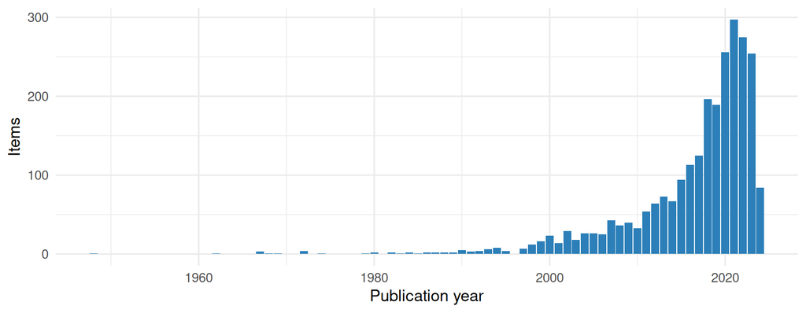

### Types of items

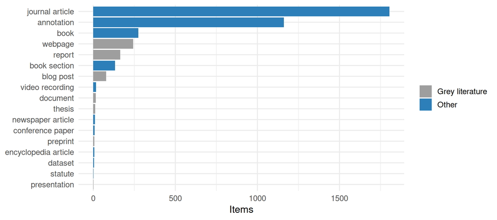

### Open access

Open access status of the publications found in OpenAlex. *Gold* and *diamond*: open in an open access journal; *hybrid*: open in a subscription journal; *green*: an open copy is in a repository; *bronze*: free to read on the publisher’s site; *closed*: not openly available.

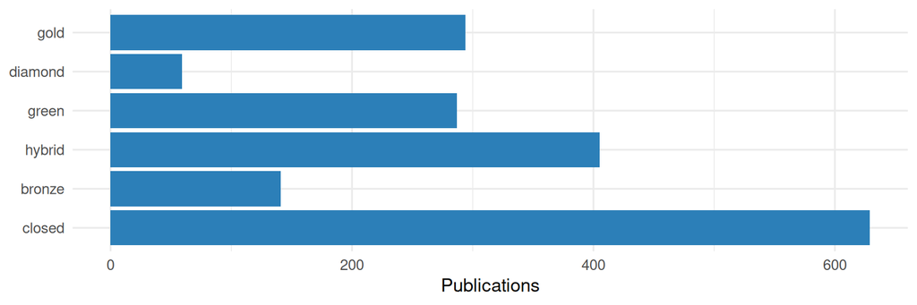

### Most frequent journals

| Journal | Items |
| --- | --- |
| Ecology and Society | 54 |
| Sustainability Science | 45 |
| Current Opinion in Environmental Sustainability | 44 |
| Environmental Science & Policy | 37 |
| Global Environmental Change | 32 |
| Ecological Economics | 30 |
| Science | 27 |
| Sustainability | 27 |
| Nature Sustainability | 23 |
| Proceedings of the National Academy of Sciences | 22 |

### Countries of the authors

Number of publications with at least one author from the country, for the publications found in OpenAlex.

| Country | Publications |
| --- | --- |
| United States | 548 |
| United Kingdom | 453 |
| Germany | 251 |
| Netherlands | 224 |
| Canada | 220 |
| Sweden | 212 |
| Australia | 211 |
| France | 144 |
| Spain | 116 |
| South Africa | 108 |
| Switzerland | 99 |
| Brazil | 84 |
| Norway | 73 |
| Denmark | 71 |
| Italy | 68 |

## How the checks work

**NoteDetails of the checks**

#### identifiers

##### DOI coverage (`met_id_doi`)

Number and share of items with a valid DOI, and items whose DOI field is filled but contains no valid DOI. DOIs are extracted with `openalexPro::extract_doi()` and lower cased.

##### ISBN coverage (`met_id_isbn`)

Number and share of items with an ISBN, overall and for the item types which should have one (`book`, `bookSection`).

##### ISSN coverage (`met_id_issn`)

Number and share of items with an ISSN, overall and for the item types which should have one (`journalArticle`, `magazineArticle`).

##### ISSN not in the standard form (`met_id_issn_form`)

Items whose ISSN field is not in the standard form: each ISSN as `1234-567X` (with hyphen, capital X), several separated by “,”. The ISSNs are checked with their check digit. If all are valid, the standard form is proposed; otherwise the item is listed with the ISSNs which are not valid.

##### DOIs in the wrong field (`met_id_doi_misplaced`)

Items with an empty DOI field but a DOI in the `Url` or `Extra` field. These DOIs are not used for the OpenAlex lookup and should be moved to the DOI field.

##### DOIs in the wrong form (`met_id_doi_form`)

Items whose DOI field contains a valid DOI, but not as a bare DOI: as a link (`https://doi.org/10.…`), with a prefix (`doi:`, `DOI`), URL-encoded (`%5B` for `[`) or with spaces or other characters around it. Citation styles add the link themselves, so a link in the DOI field appears twice in a bibliography. The bare DOI is the one recognised by `openalexPro::extract_doi()`, keeping its upper and lower case.

##### Items without identifier (`met_id_none`)

Items with none of DOI, ISBN, ISSN or Url. These items can neither be checked against OpenAlex nor easily be retrieved by readers.

##### DOIs found in OpenAlex for items without a DOI (`met_id_candidates`)

For items without a DOI, OpenAlex was searched by title (see [get_doi_candidates()]). The works found are compared with the item: title (ignoring case and punctuation), year and the surname of the first author. A work is a *likely* match if the titles are (nearly) the same (similarity at least 0.95), the years differ by at most 1 and the first authors have the same surname (year or author are not compared if the item has none), and the title has at least 4 words (short titles like “Zoonoses” are too general). It is a *possible* match if the titles are similar (at least 0.8). All likely and possible works with a DOI are kept, sorted per item, best first. DOIs used by another item in the group are noted (the item would be a duplicate).

#### metadata

##### Filled fields per item type (`met_meta_fields`)

Percentage of items with a filled field, per item type, for the main fields: Title, Author, Publication Year, Publication Title, Publisher, DOI, ISBN, ISSN, Url, Abstract Note and Language. Not every field is expected for every item type, e.g. reports have no Publication Title.

##### Problematic publication years (`met_meta_year`)

Items whose date is missing (`missing`), from whose date Zotero could not derive a year (`unparseable`), or whose year lies in the future (`future`).

##### Duplicate items (`met_meta_duplicates`)

Items which are in the group more than once, identified by the same DOI, or by the same normalised title (lower case, letters and digits only), publication year and first word of the first author.

##### Language not given as a standard code (`met_meta_language`)

Items whose language is not given as a standard language code, i.e. a two-letter ISO 639-1 code, optionally with a region (`en`, `en-US`), but e.g. as a name (`English`), a three-letter code (`eng`) or in a different spelling (`EN`, `en_us`). Citation styles and other tools only recognise the codes. Where the value is recognised, the standard code is proposed, based on the ISO 639-2 list (R package ISOcodes): codes, three-letter codes and the English names of the languages. Other values, e.g. names in the language itself, several languages or other text, are listed without a proposal.

#### openalex_check

##### Zotero DOIs found in OpenAlex (`met_check_found`)

Valid Zotero DOIs which were / were not found in OpenAlex. A DOI which is not found is either not indexed by OpenAlex or wrong.

##### Retracted works (`met_check_retracted`)

Works flagged as retracted by OpenAlex, with the key of the Zotero item(s) with the same DOI.

##### Wrong DOIs (`met_check_mismatch`)

Items whose DOI points in OpenAlex to a work with a different title or year, which usually means that the wrong DOI is attached to the item. An item is flagged when the title similarity (normalised Levenshtein distance) is below 0.8 or the years differ by more than one.

##### Item type agreement (`met_check_type`)

Zotero item type compared with the OpenAlex work type for items with the same DOI.

##### Missing dates found in OpenAlex (`met_check_date`)

Items without a date whose DOI was found in OpenAlex: the publication date in OpenAlex is proposed. OpenAlex gives 1 January when only the year is known, so such dates are proposed as the year only. Items whose DOI points to a different publication are left out.

##### Empty fields found in OpenAlex (`met_check_fill`)

Journal articles with an empty journal, volume, issue or pages field whose DOI was found in OpenAlex with these details: the values in OpenAlex are proposed. The journal is only taken if the publication is in a journal in OpenAlex (not e.g. a repository). Page ranges which end before they start (e.g. `1260-2`, shortened or wrong) are not proposed. Items whose DOI points to a different publication are left out.

##### OpenAlex ID in the Extra field (`met_check_openalex_id`)

Items whose DOI was found in OpenAlex, compared with the OpenAlex ID noted in their Extra field (a line `OpenAlex: W…`). Items without such a line can get it, which links them to OpenAlex for later checks. Items with a different ID are listed for checking: OpenAlex merges records, and the ID of a merged record redirects to the new one. Items whose DOI points to a different publication are left out.

##### OpenAlex ID in the Extra field not valid (`met_check_extra_id`)

Checks the lines `OpenAlex: …` in the Extra field (looked up by [get_extra_ids()]). A line is not valid if - it is not an OpenAlex work ID (`W` and digits), - the item has several lines with different IDs, - the ID is not in OpenAlex (wrong, or merged into another record), or - the work is a different publication: its DOI is not the DOI of the item, or, for items without DOI, its title is not similar (similarity below 0.8, see [title_similarity()]).

#### profile

##### Publication years (`met_prof_year`)

Number of items per publication year, with cumulative counts. Items without a year are counted as `NA`.

##### Open access status (`met_prof_oa`)

OpenAlex open access status (gold, diamond, green, hybrid, bronze, closed) of the works, overall and per publication year.

##### Top journals (`met_prof_journals`)

The 50 most frequent journals, from the Publication Title in Zotero and the source of the primary location in OpenAlex. Ties at rank 50 are included.

##### Author countries (`met_prof_countries`)

Number of works with at least one author affiliated with an institution in a country, per country (ISO 3166-1 alpha-2 codes from OpenAlex).

##### Item types and grey literature (`met_prof_types`)

Number of items per item type (Zotero) or work type (OpenAlex), and the share of grey literature, i.e. reports, theses, dissertations, web pages, documents, presentations, manuscripts, blog posts and preprints.

##### Languages (`met_prof_language`)

Languages as entered, and normalised to two letter codes (lower case, region removed, English spellings mapped to `en`). Inconsistent codes in the language as entered are a quality issue in themselves.

#### maintenance

##### Group activity (`met_maint_activity`)

Items added per month, and items added / modified in the 30 days before the metrics were calculated.

##### Items without tags (`met_maint_tags`)

Items without manual tags. Automatic tags, e.g. keywords imported from the publisher, are ignored.

IPBES Literature Report 0.4.0 · [source code on GitHub](https://github.com/IPBES-Data/IPBES.LiteratureReport) (© IPBES.LiteratureReport authors, [MIT licence](https://opensource.org/license/mit)) · reports and data on this website: [CC0 1.0](https://creativecommons.org/publicdomain/zero/1.0/) (no rights reserved)